# The evaluation of a brief intervention with mindset induction to reduce khat use among university students – a randomized controlled trial from Ethiopia

Analyses by: Lucas Keller

2023-03-27

### 1. Days (generalized linear mixed model analysis - “logistic regression”)

#### 1.1. Full Sample

#### 1.1.1. Model with main effects for intervention (vs. control group; *intervention*) and time (*post*). Controlling for symptom load (*SRQ_sum*) and change motivation (Taking Steps; *TS_zen*) with random intercepts and random slopes for the within factor.

```r
m_111 <- glmer(consumed ~ intervention + post
                      + SRQ_sum + TS_zen
                      + (1 + post|Code_creation),
                      subset(d, t0_Sex == 0), family = binomial(link="logit"),
                      control = glmerControl(optimizer = "bobyqa", optCtrl = list(maxfun=2e6)))
```

#### 1.1.2. Including the two-way interaction between intervention and time (main hypothesis).

```r
m_112 <- glmer(consumed ~ intervention * post
                      + SRQ_sum + TS_zen
                      + (1 + post|Code_creation),
                      subset(d, t0_Sex == 0), family = binomial(link="logit"),
                      control = glmerControl(optimizer = "bobyqa", optCtrl = list(maxfun=2e6)))
summary(m_112)
```

```
## Generalized linear mixed model fit by maximum likelihood (Laplace
##   Approximation) [glmerMod]
##  Family: binomial  ( logit )
## Formula: consumed ~ intervention * post + SRQ_sum + TS_zen + (1 + post |
##     Code_creation)
##    Data: subset(d, t0_Sex == 0)
## Control: glmerControl(optimizer = "bobyqa", optCtrl = list(maxfun = 2e+06))
##
##      AIC      BIC   logLik deviance df.resid
##  11884.0  11950.7  -5933.0  11866.0    12170
##
## Scaled residuals:
##     Min      1Q  Median      3Q     Max
## -4.7975 -0.5718  0.1238  0.5035  4.3944
##
## Random effects:
##  Groups        Name        Variance Std.Dev. Corr
##  Code_creation (Intercept) 4.824    2.196
##                post        5.955    2.440    -0.31
## Number of obs: 12179, groups:  Code_creation, 292
##
## Fixed effects:
##                   Estimate Std. Error z value Pr(>|z|)
## (Intercept)        0.27873    0.23117   1.206  0.22792
## intervention      -0.35701    0.26902  -1.327  0.18449
## post              -0.25465    0.21781  -1.169  0.24234
## SRQ_sum            0.06870    0.02323   2.957  0.00311 **
## TS_zen            -0.05009    0.01707  -2.934  0.00335 **
## intervention:post -0.65430    0.31830  -2.056  0.03982 *
## ---
## Signif. codes:  0 '***' 0.001 '**' 0.01 '*' 0.05 '.' 0.1 ' ' 1
##
## Correlation of Fixed Effects:
##             (Intr) intrvn post   SRQ_sm TS_zen
## interventin -0.546
## post        -0.264  0.227
## SRQ_sum     -0.605  0.010 -0.010
## TS_zen       0.063 -0.018  0.021 -0.108
## intrvntn:ps  0.183 -0.334 -0.680 -0.003 -0.007
```

#### 1.1.3a. Including the two- and three-way interactions with symptom load.

```r
m_113a <- glmer(consumed ~ intervention * post * SRQ_sum
                      + TS_zen
                      + (1 + post|Code_creation),
                      subset(d, t0_Sex == 0), family = binomial(link="logit"),
                      control = glmerControl(optimizer = "bobyqa", optCtrl = list(maxfun=2e6)))
summary(m_113a)
```

```
## Generalized linear mixed model fit by maximum likelihood (Laplace
##   Approximation) [glmerMod]
##  Family: binomial  ( logit )
## Formula: consumed ~ intervention * post * SRQ_sum + TS_zen + (1 + post |
##     Code_creation)
##    Data: subset(d, t0_Sex == 0)
## Control: glmerControl(optimizer = "bobyqa", optCtrl = list(maxfun = 2e+06))
##
##      AIC      BIC   logLik deviance df.resid
##  11888.6  11977.5  -5932.3  11864.6    12167
##
## Scaled residuals:
##     Min      1Q  Median      3Q     Max
## -4.6935 -0.5731  0.1234  0.5043  4.3547
##
## Random effects:
##  Groups        Name        Variance Std.Dev. Corr
##  Code_creation (Intercept) 4.803    2.192
##                post        5.949    2.439    -0.30
## Number of obs: 12179, groups:  Code_creation, 292
##
## Fixed effects:
##                             Estimate Std. Error z value Pr(>|z|)
## (Intercept)                0.3391117  0.2743341   1.236   0.2164
## intervention              -0.3648273  0.3994569  -0.913   0.3611
## post                      -0.4550387  0.3225638  -1.411   0.1583
## SRQ_sum                    0.0585202  0.0335754   1.743   0.0813 .
## TS_zen                    -0.0497543  0.0171392  -2.903   0.0037 **
## intervention:post         -0.6631636  0.4745610  -1.397   0.1623
## intervention:SRQ_sum       0.0009887  0.0491200   0.020   0.9839
## post:SRQ_sum               0.0339418  0.0396734   0.856   0.3923
## intervention:post:SRQ_sum  0.0009597  0.0582536   0.016   0.9869
## ---
## Signif. codes:  0 '***' 0.001 '**' 0.01 '*' 0.05 '.' 0.1 ' ' 1
##
## Correlation of Fixed Effects:
##             (Intr) intrvn post   SRQ_sm TS_zen intrv: i:SRQ_ p:SRQ_
## interventin -0.686
## post        -0.332  0.227
## SRQ_sum     -0.743  0.511  0.246
## TS_zen       0.089 -0.070  0.010 -0.122
## intrvntn:ps  0.225 -0.326 -0.679 -0.167 -0.008
## intrvn:SRQ_  0.508 -0.741 -0.168 -0.682  0.079  0.243
## post:SRQ_sm  0.246 -0.169 -0.737 -0.332  0.006  0.499  0.227
## intrv::SRQ_ -0.167  0.244  0.503  0.225  0.004 -0.741 -0.333 -0.679
```

#### 1.1.3b. Including the two- and three-way interactions with change motivation.

```r
m_113b <- glmer(consumed ~ intervention * post * TS_zen
                      + SRQ_sum
                      + (1 + post|Code_creation),
                      subset(d, t0_Sex == 0), family = binomial(link="logit"),
                      control = glmerControl(optimizer = "bobyqa", optCtrl = list(maxfun=2e6)))
summary(m_113b)
```

```
## Generalized linear mixed model fit by maximum likelihood (Laplace
##   Approximation) [glmerMod]
##  Family: binomial  ( logit )
## Formula: consumed ~ intervention * post * TS_zen + SRQ_sum + (1 + post |
##     Code_creation)
##    Data: subset(d, t0_Sex == 0)
## Control: glmerControl(optimizer = "bobyqa", optCtrl = list(maxfun = 2e+06))
##
##      AIC      BIC   logLik deviance df.resid
##  11885.0  11973.9  -5930.5  11861.0    12167
##
## Scaled residuals:
##     Min      1Q  Median      3Q     Max
## -4.8403 -0.5734  0.1234  0.5025  4.2805
##
## Random effects:
##  Groups        Name        Variance Std.Dev. Corr
##  Code_creation (Intercept) 4.744    2.178
##                post        5.921    2.433    -0.30
## Number of obs: 12179, groups:  Code_creation, 292
##
## Fixed effects:
##                          Estimate Std. Error z value Pr(>|z|)
## (Intercept)               0.28952    0.23027   1.257  0.20864
## intervention             -0.35759    0.26699  -1.339  0.18046
## post                     -0.24631    0.21763  -1.132  0.25774
## TS_zen                   -0.02459    0.02497  -0.985  0.32475
## SRQ_sum                   0.06625    0.02325   2.849  0.00438 **
## intervention:post        -0.64698    0.31828  -2.033  0.04208 *
## intervention:TS_zen      -0.02606    0.03556  -0.733  0.46369
## post:TS_zen              -0.03898    0.02952  -1.320  0.18670
## intervention:post:TS_zen -0.01041    0.04215  -0.247  0.80502
## ---
## Signif. codes:  0 '***' 0.001 '**' 0.01 '*' 0.05 '.' 0.1 ' ' 1
##
## Correlation of Fixed Effects:
##             (Intr) intrvn post   TS_zen SRQ_sm intrv: in:TS_ ps:TS_
## interventin -0.544
## post        -0.253  0.219
## TS_zen       0.086 -0.010  0.003
## SRQ_sum     -0.609  0.009 -0.010 -0.126
## intrvntn:ps  0.175 -0.321 -0.680  0.000 -0.002
## intrvnt:TS_ -0.059 -0.007  0.000 -0.701  0.084  0.006
## post:TS_zen -0.001  0.000  0.002 -0.325  0.005 -0.002  0.228
## intrvn::TS_ -0.001  0.006 -0.007  0.226  0.003 -0.010 -0.327 -0.697
```

#### 1.1.4. Model comparisons:

```
## Data: subset(d, t0_Sex == 0)
## Models:
## m_111: consumed ~ intervention + post + SRQ_sum + TS_zen + (1 + post | Code_creation)
## m_112: consumed ~ intervention * post + SRQ_sum + TS_zen + (1 + post | Code_creation)
## m_113a: consumed ~ intervention * post * SRQ_sum + TS_zen + (1 + post | Code_creation)
##        npar   AIC   BIC  logLik deviance  Chisq Df Pr(>Chisq)
## m_111     8 11886 11945 -5935.0    11870
## m_112     9 11884 11951 -5933.0    11866 4.0480  1    0.04422 *
## m_113a   12 11889 11978 -5932.3    11865 1.3418  3    0.71924
## ---
## Signif. codes:  0 '***' 0.001 '**' 0.01 '*' 0.05 '.' 0.1 ' ' 1
```

```
## Data: subset(d, t0_Sex == 0)
## Models:
## m_111: consumed ~ intervention + post + SRQ_sum + TS_zen + (1 + post | Code_creation)
## m_112: consumed ~ intervention * post + SRQ_sum + TS_zen + (1 + post | Code_creation)
## m_113b: consumed ~ intervention * post * TS_zen + SRQ_sum + (1 + post | Code_creation)
##        npar   AIC   BIC  logLik deviance  Chisq Df Pr(>Chisq)
## m_111     8 11886 11945 -5935.0    11870
## m_112     9 11884 11951 -5933.0    11866 4.0480  1    0.04422 *
## m_113b   12 11885 11974 -5930.5    11861 4.9369  3    0.17648
## ---
## Signif. codes:  0 '***' 0.001 '**' 0.01 '*' 0.05 '.' 0.1 ' ' 1
```

#### 1.1.5. Model overview:

```
##
## ========================================================================================
##                                      Model 1       Model 2      Model 3      Model 4
## ----------------------------------------------------------------------------------------
## (Intercept)                              0.37          0.28         0.34         0.29
##                                         (0.23)        (0.23)       (0.27)       (0.23)
## intervention                            -0.54 *       -0.36        -0.36        -0.36
##                                         (0.26)        (0.27)       (0.40)       (0.27)
## post                                    -0.56 ***     -0.25        -0.46        -0.25
##                                         (0.16)        (0.22)       (0.32)       (0.22)
## SRQ_sum                                  0.07 **       0.07 **      0.06         0.07 **
##                                         (0.02)        (0.02)       (0.03)       (0.02)
## TS_zen                                  -0.05 **      -0.05 **     -0.05 **     -0.02
##                                         (0.02)        (0.02)       (0.02)       (0.02)
## intervention:post                                     -0.65 *      -0.66        -0.65 *
##                                                       (0.32)       (0.47)       (0.32)
## intervention:SRQ_sum                                                0.00
##                                                                    (0.05)
## post:SRQ_sum                                                        0.03
##                                                                    (0.04)
## intervention:post:SRQ_sum                                           0.00
##                                                                    (0.06)
## intervention:TS_zen                                                             -0.03
##                                                                                 (0.04)
## post:TS_zen                                                                     -0.04
##                                                                                 (0.03)
## intervention:post:TS_zen                                                        -0.01
##                                                                                 (0.04)
## ----------------------------------------------------------------------------------------
## AIC                                  11886.03      11883.98     11888.64     11885.05
## BIC                                  11945.29      11950.65     11977.53     11973.94
## Log Likelihood                       -5935.02      -5932.99     -5932.32     -5930.52
## Num. obs.                            12179         12179        12179        12179
## Num. groups: Code_creation             292           292          292          292
## Var: Code_creation (Intercept)           4.87          4.82         4.80         4.74
## Var: Code_creation post                  6.02          5.96         5.95         5.92
## Cov: Code_creation (Intercept) post     -1.73         -1.67        -1.62        -1.57
## ========================================================================================
## *** p < 0.001; ** p < 0.01; * p < 0.05
```

#### 1.2. Participants in the Intervention Condition

#### 1.2.1. Model with main effects only

```r
m_121 <- glmer(consumed ~ post
                        + SRQ_sum + TS_zen
                        + (1 + post|Code_creation),
                        subset(d, t0_Sex == 0 & intervention==1), family = binomial(link="logit"),
                        control = glmerControl(optimizer = "bobyqa", optCtrl = list(maxfun=2e6)))
summary(m_121)
```

```
## Generalized linear mixed model fit by maximum likelihood (Laplace
##   Approximation) [glmerMod]
##  Family: binomial  ( logit )
## Formula: consumed ~ post + SRQ_sum + TS_zen + (1 + post | Code_creation)
##    Data: subset(d, t0_Sex == 0 & intervention == 1)
## Control: glmerControl(optimizer = "bobyqa", optCtrl = list(maxfun = 2e+06))
##
##      AIC      BIC   logLik deviance df.resid
##   5605.0   5651.4  -2795.5   5591.0     5596
##
## Scaled residuals:
##     Min      1Q  Median      3Q     Max
## -4.1948 -0.5713 -0.1697  0.5619  3.9607
##
## Random effects:
##  Groups        Name        Variance Std.Dev. Corr
##  Code_creation (Intercept) 4.173    2.043
##                post        5.479    2.341    -0.35
## Number of obs: 5603, groups:  Code_creation, 135
##
## Fixed effects:
##             Estimate Std. Error z value Pr(>|z|)
## (Intercept) -0.09217    0.26205  -0.352  0.72504
## post        -0.88924    0.22551  -3.943 8.04e-05 ***
## SRQ_sum      0.06821    0.03133   2.177  0.02947 *
## TS_zen      -0.06392    0.02246  -2.846  0.00443 **
## ---
## Signif. codes:  0 '***' 0.001 '**' 0.01 '*' 0.05 '.' 0.1 ' ' 1
##
## Correlation of Fixed Effects:
##         (Intr) post   SRQ_sm
## post    -0.250
## SRQ_sum -0.708 -0.019
## TS_zen  -0.016  0.015 -0.018
```

#### 1.2.2a. Model with Symptom Load Interaction

```r
m_122a <- glmer(consumed ~ post * SRQ_sum + TS_zen
                        + (1 + post|Code_creation),
                        subset(d, t0_Sex == 0 & intervention==1), family = binomial(link="logit"),
                        control = glmerControl(optimizer = "bobyqa", optCtrl = list(maxfun=2e6)))
summary(m_122a)
```

```
## Generalized linear mixed model fit by maximum likelihood (Laplace
##   Approximation) [glmerMod]
##  Family: binomial  ( logit )
## Formula: consumed ~ post * SRQ_sum + TS_zen + (1 + post | Code_creation)
##    Data: subset(d, t0_Sex == 0 & intervention == 1)
## Control: glmerControl(optimizer = "bobyqa", optCtrl = list(maxfun = 2e+06))
##
##      AIC      BIC   logLik deviance df.resid
##   5606.4   5659.5  -2795.2   5590.4     5595
##
## Scaled residuals:
##     Min      1Q  Median      3Q     Max
## -4.2018 -0.5727 -0.1658  0.5631  3.9287
##
## Random effects:
##  Groups        Name        Variance Std.Dev. Corr
##  Code_creation (Intercept) 4.149    2.037
##                post        5.474    2.340    -0.34
## Number of obs: 5603, groups:  Code_creation, 135
##
## Fixed effects:
##              Estimate Std. Error z value Pr(>|z|)
## (Intercept)  -0.03621    0.27162  -0.133  0.89394
## post         -1.08434    0.33593  -3.228  0.00125 **
## SRQ_sum       0.05844    0.03356   1.742  0.08158 .
## TS_zen       -0.06355    0.02247  -2.828  0.00469 **
## post:SRQ_sum  0.03258    0.04125   0.790  0.42956
## ---
## Signif. codes:  0 '***' 0.001 '**' 0.01 '*' 0.05 '.' 0.1 ' ' 1
##
## Correlation of Fixed Effects:
##             (Intr) post   SRQ_sm TS_zen
## post        -0.355
## SRQ_sum     -0.733  0.262
## TS_zen      -0.020 -0.001 -0.010
## post:SRQ_sm  0.263 -0.741 -0.366  0.016
```

#### 1.2.2b. Model with Change Motivation Interaction

```r
m_122b <- glmer(consumed ~  post * TS_zen + SRQ_sum
                        + (1 + post|Code_creation),
                        subset(d, t0_Sex == 0 & intervention==1), family = binomial(link="logit"),
                        control = glmerControl(optimizer = "bobyqa", optCtrl = list(maxfun=2e6)))
summary(m_122b)
```

```
## Generalized linear mixed model fit by maximum likelihood (Laplace
##   Approximation) [glmerMod]
##  Family: binomial  ( logit )
## Formula: consumed ~ post * TS_zen + SRQ_sum + (1 + post | Code_creation)
##    Data: subset(d, t0_Sex == 0 & intervention == 1)
## Control: glmerControl(optimizer = "bobyqa", optCtrl = list(maxfun = 2e+06))
##
##      AIC      BIC   logLik deviance df.resid
##   5604.5   5657.5  -2794.2   5588.5     5595
##
## Scaled residuals:
##     Min      1Q  Median      3Q     Max
## -4.2019 -0.5741 -0.1712  0.5652  4.0614
##
## Random effects:
##  Groups        Name        Variance Std.Dev. Corr
##  Code_creation (Intercept) 4.103    2.026
##                post        5.436    2.332    -0.33
## Number of obs: 5603, groups:  Code_creation, 135
##
## Fixed effects:
##             Estimate Std. Error z value Pr(>|z|)
## (Intercept) -0.09539    0.26087  -0.366 0.714606
## post        -0.87344    0.22507  -3.881 0.000104 ***
## TS_zen      -0.04953    0.02370  -2.090 0.036643 *
## SRQ_sum      0.06743    0.03130   2.154 0.031240 *
## post:TS_zen -0.04729    0.02917  -1.621 0.104987
## ---
## Signif. codes:  0 '***' 0.001 '**' 0.01 '*' 0.05 '.' 0.1 ' ' 1
##
## Correlation of Fixed Effects:
##             (Intr) post   TS_zen SRQ_sm
## post        -0.236
## TS_zen      -0.016  0.017
## SRQ_sum     -0.711 -0.018 -0.010
## post:TS_zen  0.004 -0.028 -0.356  0.011
```

#### 1.2.3. Model comparison:

```
## Data: subset(d, t0_Sex == 0 & intervention == 1)
## Models:
## m_121: consumed ~ post + SRQ_sum + TS_zen + (1 + post | Code_creation)
## m_122a: consumed ~ post * SRQ_sum + TS_zen + (1 + post | Code_creation)
##        npar    AIC    BIC  logLik deviance  Chisq Df Pr(>Chisq)
## m_121     7 5605.0 5651.4 -2795.5   5591.0
## m_122a    8 5606.4 5659.5 -2795.2   5590.4 0.6006  1     0.4383
```

```
## Data: subset(d, t0_Sex == 0 & intervention == 1)
## Models:
## m_121: consumed ~ post + SRQ_sum + TS_zen + (1 + post | Code_creation)
## m_122b: consumed ~ post * TS_zen + SRQ_sum + (1 + post | Code_creation)
##        npar    AIC    BIC  logLik deviance  Chisq Df Pr(>Chisq)
## m_121     7 5605.0 5651.4 -2795.5   5591.0
## m_122b    8 5604.5 5657.5 -2794.2   5588.5 2.5347  1     0.1114
```

#### 1.2.4. Model overview:

```
##
## ============================================================================
##                                      Model 1       Model 2      Model 3
## ----------------------------------------------------------------------------
## (Intercept)                             -0.09         -0.04        -0.10
##                                         (0.26)        (0.27)       (0.26)
## post                                    -0.89 ***     -1.08 **     -0.87 ***
##                                         (0.23)        (0.34)       (0.23)
## SRQ_sum                                  0.07 *        0.06         0.07 *
##                                         (0.03)        (0.03)       (0.03)
## TS_zen                                  -0.06 **      -0.06 **     -0.05 *
##                                         (0.02)        (0.02)       (0.02)
## post:SRQ_sum                                           0.03
##                                                       (0.04)
## post:TS_zen                                                        -0.05
##                                                                    (0.03)
## ----------------------------------------------------------------------------
## AIC                                   5605.02       5606.42      5604.48
## BIC                                   5651.43       5659.46      5657.53
## Log Likelihood                       -2795.51      -2795.21     -2794.24
## Num. obs.                             5603          5603         5603
## Num. groups: Code_creation             135           135          135
## Var: Code_creation (Intercept)           4.17          4.15         4.10
## Var: Code_creation post                  5.48          5.47         5.44
## Cov: Code_creation (Intercept) post     -1.65         -1.61        -1.54
## ============================================================================
## *** p < 0.001; ** p < 0.01; * p < 0.05
```

#### 1.3. Participants in the Control Condition

#### 1.3.1. Model with main effects only

```r
m_131 <- glmer(consumed ~ post
                        + SRQ_sum + TS_zen
                        + (1 + post|Code_creation),
                        subset(d, t0_Sex == 0 & intervention==0), family = binomial(link="logit"),
                        control = glmerControl(optimizer = "bobyqa", optCtrl = list(maxfun=2e6)))
summary(m_131)
```

```
## Generalized linear mixed model fit by maximum likelihood (Laplace
##   Approximation) [glmerMod]
##  Family: binomial  ( logit )
## Formula: consumed ~ post + SRQ_sum + TS_zen + (1 + post | Code_creation)
##    Data: subset(d, t0_Sex == 0 & intervention == 0)
## Control: glmerControl(optimizer = "bobyqa", optCtrl = list(maxfun = 2e+06))
##
##      AIC      BIC   logLik deviance df.resid
##   6286.0   6333.5  -3136.0   6272.0     6569
##
## Scaled residuals:
##     Min      1Q  Median      3Q     Max
## -4.8660 -0.5670  0.1243  0.4766  4.4245
##
## Random effects:
##  Groups        Name        Variance Std.Dev. Corr
##  Code_creation (Intercept) 5.372    2.318
##                post        6.431    2.536    -0.28
## Number of obs: 6576, groups:  Code_creation, 157
##
## Fixed effects:
##             Estimate Std. Error z value Pr(>|z|)
## (Intercept)  0.32244    0.28302   1.139    0.255
## post        -0.25261    0.22710  -1.112    0.266
## SRQ_sum      0.06537    0.03406   1.919    0.055 .
## TS_zen      -0.03616    0.02560  -1.413    0.158
## ---
## Signif. codes:  0 '***' 0.001 '**' 0.01 '*' 0.05 '.' 0.1 ' ' 1
##
## Correlation of Fixed Effects:
##         (Intr) post   SRQ_sm
## post    -0.208
## SRQ_sum -0.727 -0.015
## TS_zen   0.138  0.026 -0.189
```

#### 1.3.2a. Model with Symptom Load Interaction

```r
m_132a <- glmer(consumed ~ post * SRQ_sum + TS_zen
                        + (1 + post|Code_creation),
                        subset(d, t0_Sex == 0 & intervention==0), family = binomial(link="logit"),
                        control = glmerControl(optimizer = "bobyqa", optCtrl = list(maxfun=2e6)))
summary(m_132a)
```

```
## Generalized linear mixed model fit by maximum likelihood (Laplace
##   Approximation) [glmerMod]
##  Family: binomial  ( logit )
## Formula: consumed ~ post * SRQ_sum + TS_zen + (1 + post | Code_creation)
##    Data: subset(d, t0_Sex == 0 & intervention == 0)
## Control: glmerControl(optimizer = "bobyqa", optCtrl = list(maxfun = 2e+06))
##
##      AIC      BIC   logLik deviance df.resid
##   6287.2   6341.6  -3135.6   6271.2     6568
##
## Scaled residuals:
##     Min      1Q  Median      3Q     Max
## -4.7639 -0.5685  0.1259  0.4752  4.3869
##
## Random effects:
##  Groups        Name        Variance Std.Dev. Corr
##  Code_creation (Intercept) 5.355    2.314
##                post        6.424    2.535    -0.28
## Number of obs: 6576, groups:  Code_creation, 157
##
## Fixed effects:
##              Estimate Std. Error z value Pr(>|z|)
## (Intercept)   0.37900    0.29087   1.303    0.193
## post         -0.46492    0.33480  -1.389    0.165
## SRQ_sum       0.05587    0.03563   1.568    0.117
## TS_zen       -0.03597    0.02561  -1.405    0.160
## post:SRQ_sum  0.03586    0.04113   0.872    0.383
##
## Correlation of Fixed Effects:
##             (Intr) post   SRQ_sm TS_zen
## post        -0.307
## SRQ_sum     -0.745  0.224
## TS_zen       0.128  0.012 -0.172
## post:SRQ_sm  0.226 -0.735 -0.306  0.007
```

#### 1.3.2b. Model with Change Motivation Interaction

```r
m_132b <- glmer(consumed ~  post * TS_zen + SRQ_sum
                        + (1 + post|Code_creation),
                        subset(d, t0_Sex == 0 & intervention==0), family = binomial(link="logit"),
                        control = glmerControl(optimizer = "bobyqa", optCtrl = list(maxfun=2e6)))
summary(m_132b)
```

```
## Generalized linear mixed model fit by maximum likelihood (Laplace
##   Approximation) [glmerMod]
##  Family: binomial  ( logit )
## Formula: consumed ~ post * TS_zen + SRQ_sum + (1 + post | Code_creation)
##    Data: subset(d, t0_Sex == 0 & intervention == 0)
## Control: glmerControl(optimizer = "bobyqa", optCtrl = list(maxfun = 2e+06))
##
##      AIC      BIC   logLik deviance df.resid
##   6286.3   6340.6  -3135.2   6270.3     6568
##
## Scaled residuals:
##     Min      1Q  Median      3Q     Max
## -4.9001 -0.5642  0.1240  0.4779  4.3546
##
## Random effects:
##  Groups        Name        Variance Std.Dev. Corr
##  Code_creation (Intercept) 5.317    2.306
##                post        6.393    2.528    -0.27
## Number of obs: 6576, groups:  Code_creation, 157
##
## Fixed effects:
##             Estimate Std. Error z value Pr(>|z|)
## (Intercept)  0.32140    0.28211   1.139   0.2546
## post        -0.24546    0.22665  -1.083   0.2788
## TS_zen      -0.02543    0.02654  -0.958   0.3380
## SRQ_sum      0.06492    0.03402   1.908   0.0564 .
## post:TS_zen -0.04032    0.03061  -1.317   0.1877
## ---
## Signif. codes:  0 '***' 0.001 '**' 0.01 '*' 0.05 '.' 0.1 ' ' 1
##
## Correlation of Fixed Effects:
##             (Intr) post   TS_zen SRQ_sm
## post        -0.199
## TS_zen       0.133  0.006
## SRQ_sum     -0.728 -0.015 -0.173
## post:TS_zen -0.002 -0.003 -0.299  0.007
```

#### 1.3.3. Model comparison:

```
## Data: subset(d, t0_Sex == 0 & intervention == 0)
## Models:
## m_131: consumed ~ post + SRQ_sum + TS_zen + (1 + post | Code_creation)
## m_132a: consumed ~ post * SRQ_sum + TS_zen + (1 + post | Code_creation)
##        npar    AIC    BIC  logLik deviance  Chisq Df Pr(>Chisq)
## m_131     7 6286.0 6333.5 -3136.0   6272.0
## m_132a    8 6287.2 6341.6 -3135.6   6271.2 0.7325  1     0.3921
```

```
## Data: subset(d, t0_Sex == 0 & intervention == 0)
## Models:
## m_131: consumed ~ post + SRQ_sum + TS_zen + (1 + post | Code_creation)
## m_132b: consumed ~ post * TS_zen + SRQ_sum + (1 + post | Code_creation)
##        npar    AIC    BIC  logLik deviance Chisq Df Pr(>Chisq)
## m_131     7 6286.0 6333.5 -3136.0   6272.0
## m_132b    8 6286.3 6340.6 -3135.2   6270.3 1.652  1     0.1987
```

#### 1.3.4. Model overview:

```
##
## ====================================================================
##                                      Model 1    Model 2    Model 3
## --------------------------------------------------------------------
## (Intercept)                              0.32       0.38       0.32
##                                         (0.28)     (0.29)     (0.28)
## post                                    -0.25      -0.46      -0.25
##                                         (0.23)     (0.33)     (0.23)
## SRQ_sum                                  0.07       0.06       0.06
##                                         (0.03)     (0.04)     (0.03)
## TS_zen                                  -0.04      -0.04      -0.03
##                                         (0.03)     (0.03)     (0.03)
## post:SRQ_sum                                        0.04
##                                                    (0.04)
## post:TS_zen                                                   -0.04
##                                                               (0.03)
## --------------------------------------------------------------------
## AIC                                   6285.97    6287.24    6286.32
## BIC                                   6333.51    6341.57    6340.65
## Log Likelihood                       -3135.99   -3135.62   -3135.16
## Num. obs.                             6576       6576       6576
## Num. groups: Code_creation             157        157        157
## Var: Code_creation (Intercept)           5.37       5.36       5.32
## Var: Code_creation post                  6.43       6.42       6.39
## Cov: Code_creation (Intercept) post     -1.66      -1.62      -1.57
## ====================================================================
## *** p < 0.001; ** p < 0.01; * p < 0.05
```

### 2. Khat Bundles (linear mixed model analysis - “linear regression”)

#### 2.1. Full Sample

#### 2.1.1. Model with main effects for intervention (vs. control group; *intervention*) and time (*post*).

Controlling for symptom load (*SRQ_sum*) and change motivation (Taking Steps; *TS_zen*) with random intercepts and random slopes for the within factor.

```r
m_211 <- lmer(val ~ intervention + post
                        + SRQ_sum + TS_zen
                        + (1 + post|Code_creation),
                        subset(d, t0_Sex == 0),
                        REML=FALSE, control = lmerControl(optimizer = "bobyqa", optCtrl = list(maxfun=2e6)))
```

#### 2.1.2. Including the two-way interaction between intervention and time (main hypothesis).

```r
m_212 <- lmer(val ~ intervention + post
                        + intervention:post
                        + SRQ_sum + TS_zen
                        + (1 + post|Code_creation),
                        subset(d, t0_Sex == 0),
                        REML=FALSE, control = lmerControl(optimizer = "bobyqa", optCtrl = list(maxfun=2e6)))
summary(m_212)
```

```
## Linear mixed model fit by maximum likelihood . t-tests use Satterthwaite's
##   method [lmerModLmerTest]
## Formula: val ~ intervention + post + intervention:post + SRQ_sum + TS_zen +
##     (1 + post | Code_creation)
##    Data: subset(d, t0_Sex == 0)
## Control: lmerControl(optimizer = "bobyqa", optCtrl = list(maxfun = 2e+06))
##
##      AIC      BIC   logLik deviance df.resid
##  39795.3  39869.4 -19887.6  39775.3    12169
##
## Scaled residuals:
##     Min      1Q  Median      3Q     Max
## -9.5042 -0.3970 -0.1306  0.2914 12.1574
##
## Random effects:
##  Groups        Name        Variance Std.Dev. Corr
##  Code_creation (Intercept) 1.813    1.346
##                post        1.323    1.150    -0.62
##  Residual                  1.332    1.154
## Number of obs: 12179, groups:  Code_creation, 292
##
## Fixed effects:
##                     Estimate Std. Error         df t value Pr(>|t|)
## (Intercept)         0.999116   0.129533 344.490340   7.713 1.33e-13 ***
## intervention        0.038696   0.160378 290.670721   0.241  0.80951
## post               -0.197676   0.096826 291.003482  -2.042  0.04210 *
## SRQ_sum             0.024977   0.011455 292.416331   2.180  0.03002 *
## TS_zen             -0.021788   0.008371 292.306867  -2.603  0.00972 **
## intervention:post  -0.063049   0.142713 291.521361  -0.442  0.65897
## ---
## Signif. codes:  0 '***' 0.001 '**' 0.01 '*' 0.05 '.' 0.1 ' ' 1
##
## Correlation of Fixed Effects:
##             (Intr) intrvn post   SRQ_sm TS_zen
## interventin -0.574
## post        -0.516  0.416
## SRQ_sum     -0.542  0.006  0.002
## TS_zen       0.061 -0.017  0.001 -0.091
## intrvntn:ps  0.351 -0.614 -0.678 -0.003 -0.003
```

#### 2.1.3a. Including the two- and three-way interactions with symptom load.

```r
m_213a <- lmer(val ~ intervention * post
                        * SRQ_sum + TS_zen
                        + (1 + post|Code_creation),
                        subset(d, t0_Sex == 0),
                        REML=FALSE, control = lmerControl(optimizer = "bobyqa", optCtrl = list(maxfun=2e6)))
summary(m_213a)
```

```
## Linear mixed model fit by maximum likelihood . t-tests use Satterthwaite's
##   method [lmerModLmerTest]
## Formula:
## val ~ intervention * post * SRQ_sum + TS_zen + (1 + post | Code_creation)
##    Data: subset(d, t0_Sex == 0)
## Control: lmerControl(optimizer = "bobyqa", optCtrl = list(maxfun = 2e+06))
##
##      AIC      BIC   logLik deviance df.resid
##  39799.7  39896.0 -19886.9  39773.7    12166
##
## Scaled residuals:
##     Min      1Q  Median      3Q     Max
## -9.5016 -0.3971 -0.1286  0.2887 12.1600
##
## Random effects:
##  Groups        Name        Variance Std.Dev. Corr
##  Code_creation (Intercept) 1.809    1.345
##                post        1.317    1.148    -0.62
##  Residual                  1.332    1.154
## Number of obs: 12179, groups:  Code_creation, 292
##
## Fixed effects:
##                             Estimate Std. Error         df t value Pr(>|t|)
## (Intercept)                 1.019530   0.162630 292.158805   6.269  1.3e-09 ***
## intervention                0.123816   0.238311 291.757572   0.520  0.60377
## post                       -0.280116   0.143702 290.106330  -1.949  0.05223 .
## SRQ_sum                     0.021627   0.019750 292.817941   1.095  0.27440
## TS_zen                     -0.022174   0.008398 292.282797  -2.640  0.00873 **
## intervention:post          -0.073661   0.211555 291.543404  -0.348  0.72795
## intervention:SRQ_sum       -0.014081   0.028988 291.610722  -0.486  0.62751
## post:SRQ_sum                0.013553   0.017464 291.065318   0.776  0.43834
## intervention:post:SRQ_sum   0.001780   0.025711 291.202207   0.069  0.94486
## ---
## Signif. codes:  0 '***' 0.001 '**' 0.01 '*' 0.05 '.' 0.1 ' ' 1
##
## Correlation of Fixed Effects:
##             (Intr) intrvn post   SRQ_sm TS_zen intrv: i:SRQ_ p:SRQ_
## interventin -0.683
## post        -0.611  0.417
## SRQ_sum     -0.744  0.508  0.453
## TS_zen       0.084 -0.062  0.000 -0.101
## intrvntn:ps  0.415 -0.611 -0.679 -0.307 -0.003
## intrvn:SRQ_  0.507 -0.740 -0.308 -0.681  0.068  0.451
## post:SRQ_sm  0.452 -0.309 -0.740 -0.609  0.001  0.503  0.415
## intrv::SRQ_ -0.307  0.452  0.503  0.414  0.001 -0.740 -0.611 -0.679
```

#### 2.1.3b. Including the two- and three-way interactions with change motivation.

```r
m_213b <- lmer(val ~ intervention * post * TS_zen
                        + SRQ_sum
                        + (1 + post|Code_creation),
                        subset(d, t0_Sex == 0),
                        REML=FALSE, control = lmerControl(optimizer = "bobyqa", optCtrl = list(maxfun=2e6)))
summary(m_213b)
```

```
## Linear mixed model fit by maximum likelihood . t-tests use Satterthwaite's
##   method [lmerModLmerTest]
## Formula:
## val ~ intervention * post * TS_zen + SRQ_sum + (1 + post | Code_creation)
##    Data: subset(d, t0_Sex == 0)
## Control: lmerControl(optimizer = "bobyqa", optCtrl = list(maxfun = 2e+06))
##
##      AIC      BIC   logLik deviance df.resid
##  39797.3  39893.6 -19885.7  39771.3    12166
##
## Scaled residuals:
##     Min      1Q  Median      3Q     Max
## -9.5057 -0.3989 -0.1326  0.2913 12.1558
##
## Random effects:
##  Groups        Name        Variance Std.Dev. Corr
##  Code_creation (Intercept) 1.794    1.339
##                post        1.315    1.147    -0.62
##  Residual                  1.332    1.154
## Number of obs: 12179, groups:  Code_creation, 292
##
## Fixed effects:
##                            Estimate Std. Error         df t value Pr(>|t|)
## (Intercept)                1.013436   0.129177 345.034130   7.845 5.46e-14 ***
## intervention               0.035755   0.159579 291.273929   0.224   0.8229
## post                      -0.200723   0.096582 290.981645  -2.078   0.0386 *
## TS_zen                     0.001524   0.014758 292.966843   0.103   0.9178
## SRQ_sum                    0.023330   0.011458 292.373897   2.036   0.0426 *
## intervention:post         -0.058525   0.142337 291.507950  -0.411   0.6812
## intervention:TS_zen       -0.031521   0.021116 293.273667  -1.493   0.1366
## post:TS_zen               -0.015975   0.013070 290.457723  -1.222   0.2226
## intervention:post:TS_zen   0.009561   0.018772 292.032062   0.509   0.6109
## ---
## Signif. codes:  0 '***' 0.001 '**' 0.01 '*' 0.05 '.' 0.1 ' ' 1
##
## Correlation of Fixed Effects:
##             (Intr) intrvn post   TS_zen SRQ_sm intrv: in:TS_ ps:TS_
## interventin -0.573
## post        -0.514  0.415
## TS_zen       0.077 -0.017 -0.015
## SRQ_sum     -0.545  0.007  0.002 -0.103
## intrvntn:ps  0.350 -0.613 -0.679  0.011 -0.003
## intrvnt:TS_ -0.054  0.004  0.011 -0.699  0.072 -0.004
## post:TS_zen -0.013  0.010  0.027 -0.609  0.001 -0.019  0.426
## intrvn::TS_  0.008 -0.003 -0.019  0.424  0.001  0.004 -0.613 -0.696
```

#### 2.1.4. Model comparison:

```
## Data: subset(d, t0_Sex == 0)
## Models:
## m_211: val ~ intervention + post + SRQ_sum + TS_zen + (1 + post | Code_creation)
## m_212: val ~ intervention + post + intervention:post + SRQ_sum + TS_zen + (1 + post | Code_creation)
## m_213a: val ~ intervention * post * SRQ_sum + TS_zen + (1 + post | Code_creation)
##        npar   AIC   BIC logLik deviance  Chisq Df Pr(>Chisq)
## m_211     9 39793 39860 -19888    39775
## m_212    10 39795 39869 -19888    39775 0.1951  1     0.6587
## m_213a   13 39800 39896 -19887    39774 1.5740  3     0.6653
```

```
## Data: subset(d, t0_Sex == 0)
## Models:
## m_211: val ~ intervention + post + SRQ_sum + TS_zen + (1 + post | Code_creation)
## m_212: val ~ intervention + post + intervention:post + SRQ_sum + TS_zen + (1 + post | Code_creation)
## m_213b: val ~ intervention * post * TS_zen + SRQ_sum + (1 + post | Code_creation)
##        npar   AIC   BIC logLik deviance  Chisq Df Pr(>Chisq)
## m_211     9 39793 39860 -19888    39775
## m_212    10 39795 39869 -19888    39775 0.1951  1     0.6587
## m_213b   13 39797 39894 -19886    39771 3.9426  3     0.2677
```

#### 2.1.5. Model overview:

```
##
## ===============================================================================================
##                                      Model 1        Model 2        Model 3        Model 4
## -----------------------------------------------------------------------------------------------
## (Intercept)                               1.02 ***       1.00 ***       1.02 ***       1.01 ***
##                                          (0.12)         (0.13)         (0.16)         (0.13)
## intervention                             -0.00           0.04           0.12           0.04
##                                          (0.13)         (0.16)         (0.24)         (0.16)
## post                                     -0.23 **       -0.20 *        -0.28          -0.20 *
##                                          (0.07)         (0.10)         (0.14)         (0.10)
## SRQ_sum                                   0.02 *         0.02 *         0.02           0.02 *
##                                          (0.01)         (0.01)         (0.02)         (0.01)
## TS_zen                                   -0.02 **       -0.02 **       -0.02 **        0.00
##                                          (0.01)         (0.01)         (0.01)         (0.01)
## intervention:post                                       -0.06          -0.07          -0.06
##                                                         (0.14)         (0.21)         (0.14)
## intervention:SRQ_sum                                                   -0.01
##                                                                        (0.03)
## post:SRQ_sum                                                            0.01
##                                                                        (0.02)
## intervention:post:SRQ_sum                                               0.00
##                                                                        (0.03)
## intervention:TS_zen                                                                   -0.03
##                                                                                       (0.02)
## post:TS_zen                                                                           -0.02
##                                                                                       (0.01)
## intervention:post:TS_zen                                                               0.01
##                                                                                       (0.02)
## -----------------------------------------------------------------------------------------------
## AIC                                   39793.48       39795.29       39799.71       39797.34
## BIC                                   39860.15       39869.36       39896.01       39893.64
## Log Likelihood                       -19887.74      -19887.64      -19886.86      -19885.67
## Num. obs.                             12179          12179          12179          12179
## Num. groups: Code_creation              292            292            292            292
## Var: Code_creation (Intercept)            1.81           1.81           1.81           1.79
## Var: Code_creation post                   1.32           1.32           1.32           1.31
## Cov: Code_creation (Intercept) post      -0.97          -0.97          -0.96          -0.96
## Var: Residual                             1.33           1.33           1.33           1.33
## ===============================================================================================
## *** p < 0.001; ** p < 0.01; * p < 0.05
```

#### 2.2. Participants in the Intervention Condition

#### 2.2.1. Model with main effects only

```r
m_221 <- lmer(val ~ post
                    + SRQ_sum + TS_zen
                    + (1 + post|Code_creation),
                    subset(d, t0_Sex == 0 & intervention == 1),
                    REML=FALSE, control = lmerControl(optimizer = "bobyqa", optCtrl = list(maxfun=2e6)))
summary(m_221)
```

```
## Linear mixed model fit by maximum likelihood . t-tests use Satterthwaite's
##   method [lmerModLmerTest]
## Formula: val ~ post + SRQ_sum + TS_zen + (1 + post | Code_creation)
##    Data: subset(d, t0_Sex == 0 & intervention == 1)
## Control: lmerControl(optimizer = "bobyqa", optCtrl = list(maxfun = 2e+06))
##
##      AIC      BIC   logLik deviance df.resid
##  18302.2  18355.3  -9143.1  18286.2     5595
##
## Scaled residuals:
##     Min      1Q  Median      3Q     Max
## -4.2780 -0.3763 -0.1375  0.2912  9.6104
##
## Random effects:
##  Groups        Name        Variance Std.Dev. Corr
##  Code_creation (Intercept) 1.814    1.347
##                post        1.419    1.191    -0.49
##  Residual                  1.320    1.149
## Number of obs: 5603, groups:  Code_creation, 135
##
## Fixed effects:
##              Estimate Std. Error        df t value Pr(>|t|)
## (Intercept)   1.09577    0.16273 153.21272   6.734 3.13e-10 ***
## post         -0.26104    0.10817 134.36518  -2.413   0.0172 *
## SRQ_sum       0.01571    0.01857 135.09949   0.846   0.3992
## TS_zen       -0.03339    0.01321 135.58233  -2.527   0.0126 *
## ---
## Signif. codes:  0 '***' 0.001 '**' 0.01 '*' 0.05 '.' 0.1 ' ' 1
##
## Correlation of Fixed Effects:
##         (Intr) post   SRQ_sm
## post    -0.352
## SRQ_sum -0.690 -0.003
## TS_zen  -0.012 -0.005  0.001
```

#### 2.2.2a. Model with Symptom Load Interaction

```r
m_222a <- lmer(val ~ post
                     * SRQ_sum + TS_zen
                     + (1 + post|Code_creation),
                     subset(d, t0_Sex == 0 & intervention == 1),
                     REML=FALSE, control = lmerControl(optimizer = "bobyqa", optCtrl = list(maxfun=2e6)))
summary(m_222a)
```

```
## Linear mixed model fit by maximum likelihood . t-tests use Satterthwaite's
##   method [lmerModLmerTest]
## Formula: val ~ post * SRQ_sum + TS_zen + (1 + post | Code_creation)
##    Data: subset(d, t0_Sex == 0 & intervention == 1)
## Control: lmerControl(optimizer = "bobyqa", optCtrl = list(maxfun = 2e+06))
##
##      AIC      BIC   logLik deviance df.resid
##  18303.6  18363.3  -9142.8  18285.6     5594
##
## Scaled residuals:
##     Min      1Q  Median      3Q     Max
## -4.2725 -0.3788 -0.1380  0.2891  9.6153
##
## Random effects:
##  Groups        Name        Variance Std.Dev. Corr
##  Code_creation (Intercept) 1.812    1.346
##                post        1.411    1.188    -0.49
##  Residual                  1.320    1.149
## Number of obs: 5603, groups:  Code_creation, 135
##
## Fixed effects:
##               Estimate Std. Error        df t value Pr(>|t|)
## (Intercept)    1.14516    0.17421 134.72908   6.573 9.91e-10 ***
## post          -0.35498    0.16025 134.57604  -2.215   0.0284 *
## SRQ_sum        0.00755    0.02123 134.40507   0.356   0.7227
## TS_zen        -0.03336    0.01321 135.56282  -2.524   0.0127 *
## post:SRQ_sum   0.01544    0.01947 133.94538   0.793   0.4293
## ---
## Signif. codes:  0 '***' 0.001 '**' 0.01 '*' 0.05 '.' 0.1 ' ' 1
##
## Correlation of Fixed Effects:
##             (Intr) post   SRQ_sm TS_zen
## post        -0.485
## SRQ_sum     -0.737  0.356
## TS_zen      -0.010 -0.006 -0.001
## post:SRQ_sm  0.358 -0.739 -0.484  0.003
```

#### 2.2.2b. Model with Change Motivation Interaction

```r
m_222b <- lmer(val ~ post *TS_zen
                        + SRQ_sum
                        + (1 + post|Code_creation),
                        subset(d, t0_Sex == 0 & intervention == 1),
                        REML=FALSE, control = lmerControl(optimizer = "bobyqa", optCtrl = list(maxfun=2e6)))
summary(m_222b)
```

```
## Linear mixed model fit by maximum likelihood . t-tests use Satterthwaite's
##   method [lmerModLmerTest]
## Formula: val ~ post * TS_zen + SRQ_sum + (1 + post | Code_creation)
##    Data: subset(d, t0_Sex == 0 & intervention == 1)
## Control: lmerControl(optimizer = "bobyqa", optCtrl = list(maxfun = 2e+06))
##
##      AIC      BIC   logLik deviance df.resid
##  18304.0  18363.7  -9143.0  18286.0     5594
##
## Scaled residuals:
##     Min      1Q  Median      3Q     Max
## -4.2840 -0.3783 -0.1378  0.2918  9.6098
##
## Random effects:
##  Groups        Name        Variance Std.Dev. Corr
##  Code_creation (Intercept) 1.813    1.346
##                post        1.416    1.190    -0.49
##  Residual                  1.320    1.149
## Number of obs: 5603, groups:  Code_creation, 135
##
## Fixed effects:
##               Estimate Std. Error         df t value Pr(>|t|)
## (Intercept)   1.095663   0.162704 153.232500   6.734 3.12e-10 ***
## post         -0.260095   0.108109 134.371973  -2.406   0.0175 *
## TS_zen       -0.029985   0.015175 135.630523  -1.976   0.0502 .
## SRQ_sum       0.015681   0.018571 135.110270   0.844   0.3999
## post:TS_zen  -0.006359   0.013924 135.156863  -0.457   0.6486
## ---
## Signif. codes:  0 '***' 0.001 '**' 0.01 '*' 0.05 '.' 0.1 ' ' 1
##
## Correlation of Fixed Effects:
##             (Intr) post   TS_zen SRQ_sm
## post        -0.351
## TS_zen      -0.011  0.005
## SRQ_sum     -0.690 -0.003 -0.001
## post:TS_zen  0.001 -0.019 -0.492  0.003
```

#### 2.2.3. Model comparison:

```
## Data: subset(d, t0_Sex == 0 & intervention == 1)
## Models:
## m_221: val ~ post + SRQ_sum + TS_zen + (1 + post | Code_creation)
## m_222a: val ~ post * SRQ_sum + TS_zen + (1 + post | Code_creation)
##        npar   AIC   BIC  logLik deviance  Chisq Df Pr(>Chisq)
## m_221     8 18302 18355 -9143.1    18286
## m_222a    9 18304 18363 -9142.8    18286 0.6267  1     0.4286
```

```
## Data: subset(d, t0_Sex == 0 & intervention == 1)
## Models:
## m_221: val ~ post + SRQ_sum + TS_zen + (1 + post | Code_creation)
## m_222b: val ~ post * TS_zen + SRQ_sum + (1 + post | Code_creation)
##        npar   AIC   BIC  logLik deviance  Chisq Df Pr(>Chisq)
## m_221     8 18302 18355 -9143.1    18286
## m_222b    9 18304 18364 -9143.0    18286 0.2084  1      0.648
```

#### 2.2.4. Model overview:

```
##
## =============================================================================
##                                      Model 1       Model 2       Model 3
## -----------------------------------------------------------------------------
## (Intercept)                              1.10 ***      1.15 ***      1.10 ***
##                                         (0.16)        (0.17)        (0.16)
## post                                    -0.26 *       -0.35 *       -0.26 *
##                                         (0.11)        (0.16)        (0.11)
## SRQ_sum                                  0.02          0.01          0.02
##                                         (0.02)        (0.02)        (0.02)
## TS_zen                                  -0.03 *       -0.03 *       -0.03 *
##                                         (0.01)        (0.01)        (0.02)
## post:SRQ_sum                                           0.02
##                                                       (0.02)
## post:TS_zen                                                         -0.01
##                                                                     (0.01)
## -----------------------------------------------------------------------------
## AIC                                  18302.23      18303.60      18304.02
## BIC                                  18355.28      18363.28      18363.70
## Log Likelihood                       -9143.11      -9142.80      -9143.01
## Num. obs.                             5603          5603          5603
## Num. groups: Code_creation             135           135           135
## Var: Code_creation (Intercept)           1.81          1.81          1.81
## Var: Code_creation post                  1.42          1.41          1.42
## Cov: Code_creation (Intercept) post     -0.78         -0.78         -0.78
## Var: Residual                            1.32          1.32          1.32
## =============================================================================
## *** p < 0.001; ** p < 0.01; * p < 0.05
```

#### 2.3. Participants in the Control Condition

#### 2.3.1. Model with main effects only

```r
m_231 <- lmer(val ~ post
                    + SRQ_sum + TS_zen
                    + (1 + post|Code_creation),
                    subset(d, t0_Sex == 0 & intervention == 0),
                    REML=FALSE, control = lmerControl(optimizer = "bobyqa", optCtrl = list(maxfun=2e6)))
summary(m_231)
```

```
## Linear mixed model fit by maximum likelihood . t-tests use Satterthwaite's
##   method [lmerModLmerTest]
## Formula: val ~ post + SRQ_sum + TS_zen + (1 + post | Code_creation)
##    Data: subset(d, t0_Sex == 0 & intervention == 0)
## Control: lmerControl(optimizer = "bobyqa", optCtrl = list(maxfun = 2e+06))
##
##      AIC      BIC   logLik deviance df.resid
##  21483.3  21537.6 -10733.6  21467.3     6568
##
## Scaled residuals:
##     Min      1Q  Median      3Q     Max
## -9.4774 -0.4200 -0.1306  0.2930 12.0997
##
## Random effects:
##  Groups        Name        Variance Std.Dev. Corr
##  Code_creation (Intercept) 1.788    1.337
##                post        1.241    1.114    -0.75
##  Residual                  1.342    1.159
## Number of obs: 6576, groups:  Code_creation, 157
##
## Fixed effects:
##              Estimate Std. Error        df t value Pr(>|t|)
## (Intercept)   0.96467    0.13641 208.35975   7.072 2.28e-11 ***
## post         -0.19713    0.09407 157.22448  -2.096   0.0377 *
## SRQ_sum       0.03087    0.01354 157.11634   2.280   0.0240 *
## TS_zen       -0.01289    0.01015 156.76762  -1.271   0.2057
## ---
## Signif. codes:  0 '***' 0.001 '**' 0.01 '*' 0.05 '.' 0.1 ' ' 1
##
## Correlation of Fixed Effects:
##         (Intr) post   SRQ_sm
## post    -0.581
## SRQ_sum -0.609  0.003
## TS_zen   0.120  0.002 -0.175
```

#### 2.3.2a. Model with Symptom Load Interaction

```r
m_232a <- lmer(val ~ post
                        * SRQ_sum + TS_zen
                        + (1 + post|Code_creation),
                        subset(d, t0_Sex == 0 & intervention == 0),
                        REML=FALSE, control = lmerControl(optimizer = "bobyqa", optCtrl = list(maxfun=2e6)))
summary(m_232a)
```

```
## Linear mixed model fit by maximum likelihood . t-tests use Satterthwaite's
##   method [lmerModLmerTest]
## Formula: val ~ post * SRQ_sum + TS_zen + (1 + post | Code_creation)
##    Data: subset(d, t0_Sex == 0 & intervention == 0)
## Control: lmerControl(optimizer = "bobyqa", optCtrl = list(maxfun = 2e+06))
##
##      AIC      BIC   logLik deviance df.resid
##  21484.7  21545.8 -10733.3  21466.7     6567
##
## Scaled residuals:
##     Min      1Q  Median      3Q     Max
## -9.4745 -0.4225 -0.1279  0.2974 12.1027
##
## Random effects:
##  Groups        Name        Variance Std.Dev. Corr
##  Code_creation (Intercept) 1.784    1.336
##                post        1.236    1.112    -0.75
##  Residual                  1.342    1.159
## Number of obs: 6576, groups:  Code_creation, 157
##
## Fixed effects:
##               Estimate Std. Error        df t value Pr(>|t|)
## (Intercept)    1.03466    0.16181 157.75275   6.394 1.74e-09 ***
## post          -0.28018    0.13970 156.75341  -2.006   0.0466 *
## SRQ_sum        0.01943    0.01967 158.49628   0.988   0.3247
## TS_zen        -0.01288    0.01015 156.78454  -1.270   0.2061
## post:SRQ_sum   0.01362    0.01697 157.30371   0.803   0.4234
## ---
## Signif. codes:  0 '***' 0.001 '**' 0.01 '*' 0.05 '.' 0.1 ' ' 1
##
## Correlation of Fixed Effects:
##             (Intr) post   SRQ_sm TS_zen
## post        -0.728
## SRQ_sum     -0.745  0.538
## TS_zen       0.102  0.000 -0.122
## post:SRQ_sm  0.539 -0.741 -0.725  0.002
```

#### 2.3.2b. Model with Change Motivation Interaction

```r
m_232b <- lmer(val ~ post *TS_zen
                        + SRQ_sum
                        + (1 + post|Code_creation),
                        subset(d, t0_Sex == 0 & intervention == 0),
                        REML=FALSE, control = lmerControl(optimizer = "bobyqa", optCtrl = list(maxfun=2e6)))
summary(m_232b)
```

```
## Linear mixed model fit by maximum likelihood . t-tests use Satterthwaite's
##   method [lmerModLmerTest]
## Formula: val ~ post * TS_zen + SRQ_sum + (1 + post | Code_creation)
##    Data: subset(d, t0_Sex == 0 & intervention == 0)
## Control: lmerControl(optimizer = "bobyqa", optCtrl = list(maxfun = 2e+06))
##
##      AIC      BIC   logLik deviance df.resid
##  21483.7  21544.8 -10732.9  21465.7     6567
##
## Scaled residuals:
##     Min      1Q  Median      3Q     Max
## -9.4783 -0.4124 -0.1251  0.2977 12.0988
##
## Random effects:
##  Groups        Name        Variance Std.Dev. Corr
##  Code_creation (Intercept) 1.778    1.333
##                post        1.227    1.108    -0.75
##  Residual                  1.342    1.159
## Number of obs: 6576, groups:  Code_creation, 157
##
## Fixed effects:
##               Estimate Std. Error         df t value Pr(>|t|)
## (Intercept)  9.673e-01  1.362e-01  2.087e+02   7.102  1.9e-11 ***
## post        -2.003e-01  9.363e-02  1.572e+02  -2.139   0.0340 *
## TS_zen       5.252e-04  1.473e-02  1.590e+02   0.036   0.9716
## SRQ_sum      3.084e-02  1.354e-02  1.571e+02   2.277   0.0242 *
## post:TS_zen -1.594e-02  1.267e-02  1.569e+02  -1.257   0.2105
## ---
## Signif. codes:  0 '***' 0.001 '**' 0.01 '*' 0.05 '.' 0.1 ' ' 1
##
## Correlation of Fixed Effects:
##             (Intr) post   TS_zen SRQ_sm
## post        -0.580
## TS_zen       0.094 -0.018
## SRQ_sum     -0.610  0.003 -0.122
## post:TS_zen -0.016  0.027 -0.725  0.002
```

#### 2.3.3. Model comparison:

```
## Data: subset(d, t0_Sex == 0 & intervention == 0)
## Models:
## m_231: val ~ post + SRQ_sum + TS_zen + (1 + post | Code_creation)
## m_232a: val ~ post * SRQ_sum + TS_zen + (1 + post | Code_creation)
##        npar   AIC   BIC logLik deviance  Chisq Df Pr(>Chisq)
## m_231     8 21483 21538 -10734    21467
## m_232a    9 21485 21546 -10733    21467 0.6431  1     0.4226
```

```
## Data: subset(d, t0_Sex == 0 & intervention == 0)
## Models:
## m_231: val ~ post + SRQ_sum + TS_zen + (1 + post | Code_creation)
## m_232b: val ~ post * TS_zen + SRQ_sum + (1 + post | Code_creation)
##        npar   AIC   BIC logLik deviance  Chisq Df Pr(>Chisq)
## m_231     8 21483 21538 -10734    21467
## m_232b    9 21484 21545 -10733    21466 1.5728  1     0.2098
```

#### 2.3.4. Model overview:

```
##
## ================================================================================
##                                      Model 1        Model 2        Model 3
## --------------------------------------------------------------------------------
## (Intercept)                               0.96 ***       1.03 ***       0.97 ***
##                                          (0.14)         (0.16)         (0.14)
## post                                     -0.20 *        -0.28 *        -0.20 *
##                                          (0.09)         (0.14)         (0.09)
## SRQ_sum                                   0.03 *         0.02           0.03 *
##                                          (0.01)         (0.02)         (0.01)
## TS_zen                                   -0.01          -0.01           0.00
##                                          (0.01)         (0.01)         (0.01)
## post:SRQ_sum                                             0.01
##                                                         (0.02)
## post:TS_zen                                                            -0.02
##                                                                        (0.01)
## --------------------------------------------------------------------------------
## AIC                                   21483.29       21484.65       21483.72
## BIC                                   21537.62       21545.77       21544.84
## Log Likelihood                       -10733.65      -10733.33      -10732.86
## Num. obs.                              6576           6576           6576
## Num. groups: Code_creation              157            157            157
## Var: Code_creation (Intercept)            1.79           1.78           1.78
## Var: Code_creation post                   1.24           1.24           1.23
## Cov: Code_creation (Intercept) post      -1.12          -1.11          -1.11
## Var: Residual                             1.34           1.34           1.34
## ================================================================================
## *** p < 0.001; ** p < 0.01; * p < 0.05
```

### 3. Plots

#### Full Model (Days): Interaction Intervention x Time

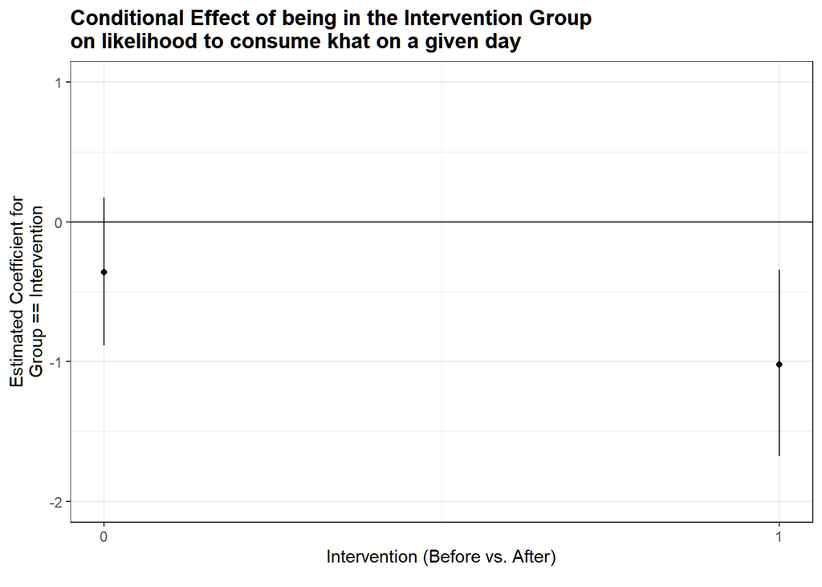

#### Full Model (Bundles): Interaction Intervention x Time

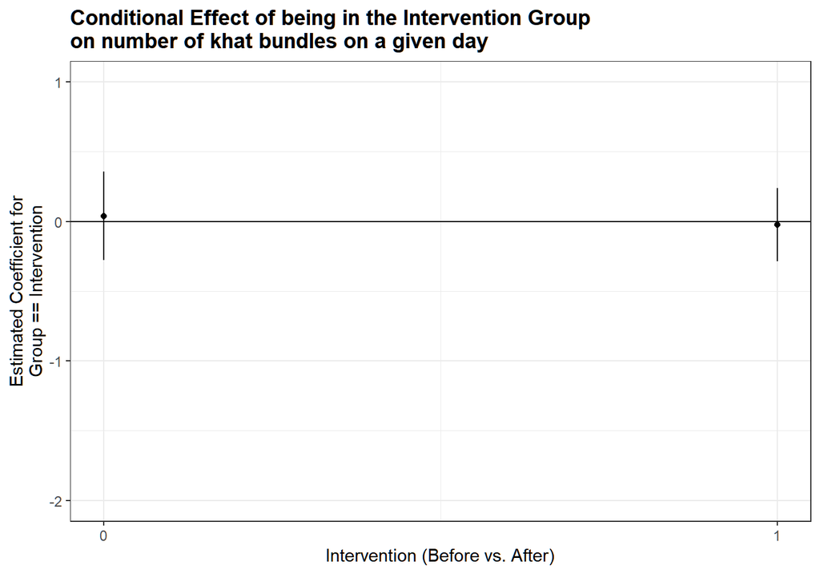

#### Full Model (Days): Interaction Intervention x Symptom Load

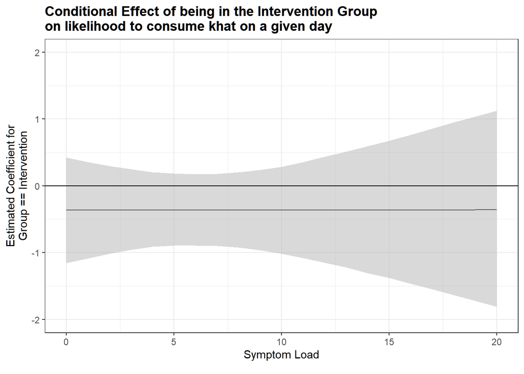

#### Full Model (Days): Interaction Intervention x Symptom Load

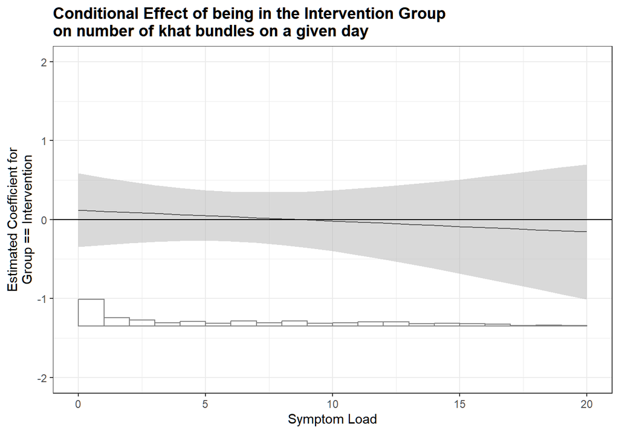

#### Full Model (Days): Interaction Intervention x Change Motivation

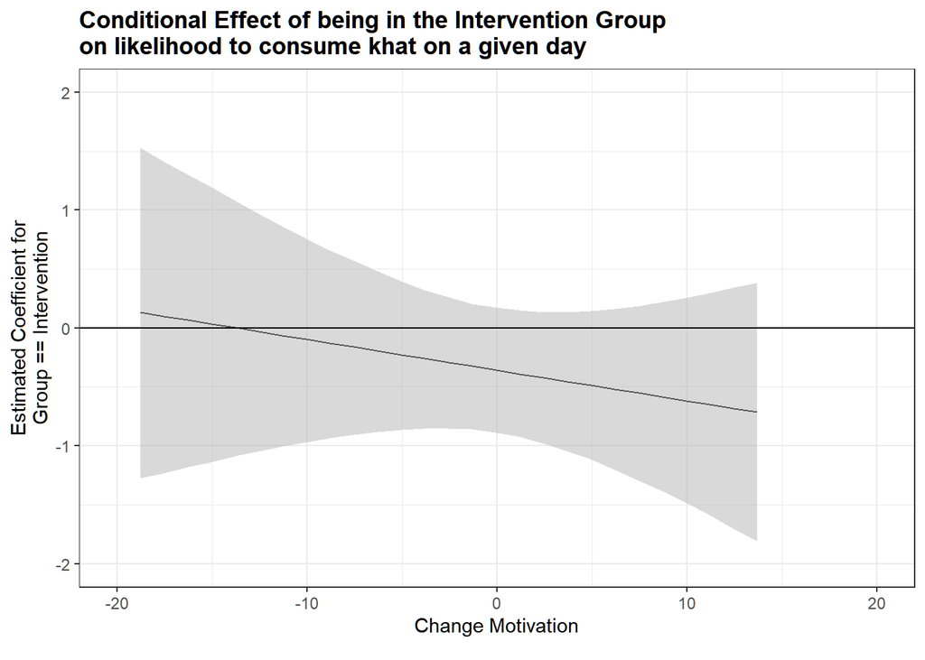

#### Full Model (Days): Interaction Intervention x Change Motivation

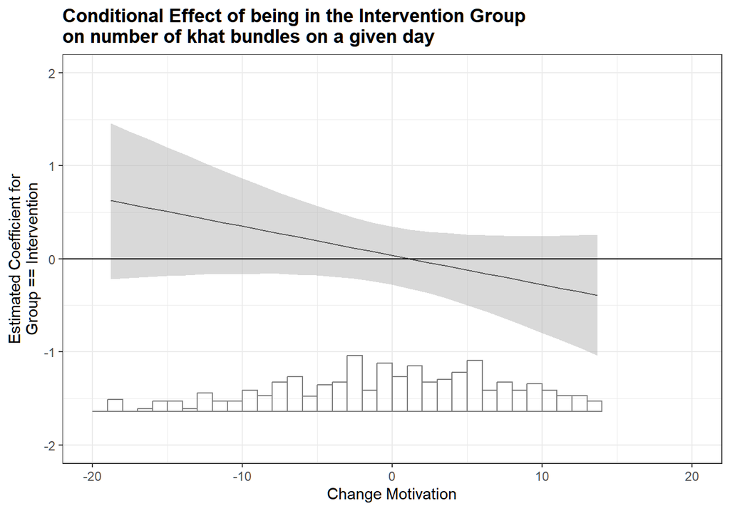

### 4. Legacy: Mindset Effects Days & Bundles

#### 4.1. Full Sample (Days)

#### 4.1.1. Model with main effects for intervention (vs. control group; *intervention*), mindset condition (implemental vs. deliberative mindset; *imp*) and time (*post*).

Controlling for symptom load (*SRQ_sum*) and change motivation (Taking Steps; *TS_zen*) with random intercepts and random slopes for the within factor.

```r
m_411 <- glmer(consumed ~ intervention + post + imp
                      + SRQ_sum + TS_zen
                      + (1 + post|Code_creation),
                      subset(d, mindset_error==0 & t0_Sex == 0), family = binomial(link="logit"),
                      control = glmerControl(optimizer = "bobyqa", optCtrl = list(maxfun=2e6)))
```

#### 4.1.2. Including the two-way interaction between intervention and time (main hypothesis).

```r
m_412 <- glmer(consumed ~ intervention + post + imp
                      + intervention:post
                      + SRQ_sum + TS_zen
                      + (1 + post|Code_creation),
                      subset(d, mindset_error==0 & t0_Sex == 0), family = binomial(link="logit"),
                      control = glmerControl(optimizer = "bobyqa", optCtrl = list(maxfun=2e6)))
summary(m_412)
```

```
## Generalized linear mixed model fit by maximum likelihood (Laplace
##   Approximation) [glmerMod]
##  Family: binomial  ( logit )
## Formula: consumed ~ intervention + post + imp + intervention:post + SRQ_sum +
##     TS_zen + (1 + post | Code_creation)
##    Data: subset(d, mindset_error == 0 & t0_Sex == 0)
## Control: glmerControl(optimizer = "bobyqa", optCtrl = list(maxfun = 2e+06))
##
##      AIC      BIC   logLik deviance df.resid
##  11018.5  11091.8  -5499.3  10998.5    11161
##
## Scaled residuals:
##     Min      1Q  Median      3Q     Max
## -4.7620 -0.5714  0.1217  0.5222  4.1411
##
## Random effects:
##  Groups        Name        Variance Std.Dev. Corr
##  Code_creation (Intercept) 4.699    2.168
##                post        5.867    2.422    -0.34
## Number of obs: 11171, groups:  Code_creation, 268
##
## Fixed effects:
##                   Estimate Std. Error z value Pr(>|z|)
## (Intercept)        0.17806    0.27079   0.658  0.51082
## intervention      -0.35972    0.27903  -1.289  0.19735
## post              -0.35477    0.22665  -1.565  0.11751
## imp                0.22528    0.26128   0.862  0.38858
## SRQ_sum            0.05717    0.02383   2.399  0.01645 *
## TS_zen            -0.04647    0.01728  -2.689  0.00717 **
## intervention:post -0.50926    0.32895  -1.548  0.12159
## ---
## Signif. codes:  0 '***' 0.001 '**' 0.01 '*' 0.05 '.' 0.1 ' ' 1
##
## Correlation of Fixed Effects:
##             (Intr) intrvn post   imp    SRQ_sm TS_zen
## interventin -0.425
## post        -0.252  0.246
## imp         -0.480 -0.119 -0.008
## SRQ_sum     -0.558 -0.002 -0.004  0.077
## TS_zen       0.077 -0.032  0.018 -0.009 -0.111
## intrvntn:ps  0.176 -0.359 -0.685  0.003 -0.006 -0.005
```

#### 4.1.3. Including the two- and three-way interactions with mindset.

```r
m_413 <- glmer(consumed ~ intervention * post * imp
                      + SRQ_sum + TS_zen
                      + (1 + post|Code_creation),
                      subset(d, mindset_error==0 & t0_Sex == 0), family = binomial(link="logit"),
                      control = glmerControl(optimizer = "bobyqa", optCtrl = list(maxfun=2e6)))
summary(m_413)
```

```
## Generalized linear mixed model fit by maximum likelihood (Laplace
##   Approximation) [glmerMod]
##  Family: binomial  ( logit )
## Formula: consumed ~ intervention * post * imp + SRQ_sum + TS_zen + (1 +
##     post | Code_creation)
##    Data: subset(d, mindset_error == 0 & t0_Sex == 0)
## Control: glmerControl(optimizer = "bobyqa", optCtrl = list(maxfun = 2e+06))
##
##      AIC      BIC   logLik deviance df.resid
##  11023.1  11118.3  -5498.5  10997.1    11158
##
## Scaled residuals:
##     Min      1Q  Median      3Q     Max
## -4.7430 -0.5730  0.1239  0.5216  4.1071
##
## Random effects:
##  Groups        Name        Variance Std.Dev. Corr
##  Code_creation (Intercept) 4.692    2.166
##                post        5.858    2.420    -0.34
## Number of obs: 11171, groups:  Code_creation, 268
##
## Fixed effects:
##                       Estimate Std. Error z value Pr(>|z|)
## (Intercept)            0.22415    0.29913   0.749   0.4536
## intervention          -0.37008    0.40738  -0.908   0.3637
## post                  -0.37327    0.30802  -1.212   0.2256
## imp                    0.12229    0.38204   0.320   0.7489
## SRQ_sum                0.05733    0.02384   2.404   0.0162 *
## TS_zen                -0.04589    0.01739  -2.640   0.0083 **
## intervention:post     -0.81826    0.48168  -1.699   0.0894 .
## intervention:imp       0.03854    0.56183   0.069   0.9453
## post:imp               0.04293    0.45132   0.095   0.9242
## intervention:post:imp  0.51952    0.66253   0.784   0.4330
## ---
## Signif. codes:  0 '***' 0.001 '**' 0.01 '*' 0.05 '.' 0.1 ' ' 1
##
## Correlation of Fixed Effects:
##             (Intr) intrvn post   imp    SRQ_sm TS_zen intrvntn:p intrvntn:m
## interventin -0.548
## post        -0.308  0.224
## imp         -0.608  0.434  0.239
## SRQ_sum     -0.500 -0.007 -0.003  0.044
## TS_zen       0.106 -0.097  0.016 -0.068 -0.109
## intrvntn:ps  0.199 -0.354 -0.638 -0.153 -0.004 -0.003
## intrvntn:mp  0.398 -0.728 -0.161 -0.682  0.007  0.102  0.257
## post:imp     0.209 -0.153 -0.678 -0.356  0.000 -0.004  0.433      0.242
## intrvntn:p: -0.143  0.258  0.463  0.243  0.001  0.000 -0.726     -0.356
##             pst:mp
## interventin
## post
## imp
## SRQ_sum
## TS_zen
## intrvntn:ps
## intrvntn:mp
## post:imp
## intrvntn:p: -0.681
```

#### 4.1.4. Model comparison:

```
## Data: subset(d, mindset_error == 0 & t0_Sex == 0)
## Models:
## m_411: consumed ~ intervention + post + imp + SRQ_sum + TS_zen + (1 + post | Code_creation)
## m_412: consumed ~ intervention + post + imp + intervention:post + SRQ_sum + TS_zen + (1 + post | Code_creation)
## m_413: consumed ~ intervention * post * imp + SRQ_sum + TS_zen + (1 + post | Code_creation)
##       npar   AIC   BIC  logLik deviance  Chisq Df Pr(>Chisq)
## m_411    9 11019 11085 -5500.4    11001
## m_412   10 11018 11092 -5499.3    10998 2.3100  1     0.1285
## m_413   13 11023 11118 -5498.5    10997 1.4508  3     0.6937
```

#### 4.1.5. Model overview:

```
##
## ===========================================================================
##                                      Model 1       Model 2      Model 3
## ---------------------------------------------------------------------------
## (Intercept)                              0.25          0.18         0.22
##                                         (0.27)        (0.27)       (0.30)
## intervention                            -0.51 *       -0.36        -0.37
##                                         (0.26)        (0.28)       (0.41)
## post                                    -0.60 ***     -0.35        -0.37
##                                         (0.17)        (0.23)       (0.31)
## imp                                      0.23          0.23         0.12
##                                         (0.26)        (0.26)       (0.38)
## SRQ_sum                                  0.06 *        0.06 *       0.06 *
##                                         (0.02)        (0.02)       (0.02)
## TS_zen                                  -0.05 **      -0.05 **     -0.05 **
##                                         (0.02)        (0.02)       (0.02)
## intervention:post                                     -0.51        -0.82
##                                                       (0.33)       (0.48)
## intervention:imp                                                    0.04
##                                                                    (0.56)
## post:imp                                                            0.04
##                                                                    (0.45)
## intervention:post:imp                                               0.52
##                                                                    (0.66)
## ---------------------------------------------------------------------------
## AIC                                  11018.85      11018.54     11023.09
## BIC                                  11084.74      11091.75     11118.27
## Log Likelihood                       -5500.43      -5499.27     -5498.55
## Num. obs.                            11171         11171        11171
## Num. groups: Code_creation             268           268          268
## Var: Code_creation (Intercept)           4.73          4.70         4.69
## Var: Code_creation post                  5.92          5.87         5.86
## Cov: Code_creation (Intercept) post     -1.83         -1.79        -1.77
## ===========================================================================
## *** p < 0.001; ** p < 0.01; * p < 0.05
```

#### 4.2. Participants in the Intervention Condition

#### 4.2.1. Model with main effects only

```r
m_421 <- glmer(consumed ~ post + imp
                        + SRQ_sum + TS_zen
                        + (1 + post|Code_creation),
                        subset(d, mindset_error==0 & t0_Sex == 0 & intervention==1), family = binomial(link="logit"),
                        control = glmerControl(optimizer = "bobyqa", optCtrl = list(maxfun=2e6)))
```

#### 4.2.2. Model with two-way Interaction

```r
m_422 <- glmer(consumed ~ post * imp + SRQ_sum + TS_zen
                        + (1 + post|Code_creation),
                        subset(d, mindset_error==0 & t0_Sex == 0 & intervention==1), family = binomial(link="logit"),
                        control = glmerControl(optimizer = "bobyqa", optCtrl = list(maxfun=2e6)))
summary(m_422)
```

```
## Generalized linear mixed model fit by maximum likelihood (Laplace
##   Approximation) [glmerMod]
##  Family: binomial  ( logit )
## Formula: consumed ~ post * imp + SRQ_sum + TS_zen + (1 + post | Code_creation)
##    Data: subset(d, mindset_error == 0 & t0_Sex == 0 & intervention ==      1)
## Control: glmerControl(optimizer = "bobyqa", optCtrl = list(maxfun = 2e+06))
##
##      AIC      BIC   logLik deviance df.resid
##   5254.8   5313.9  -2618.4   5236.8     5216
##
## Scaled residuals:
##     Min      1Q  Median      3Q     Max
## -4.1920 -0.5670 -0.1931  0.5727  3.9696
##
## Random effects:
##  Groups        Name        Variance Std.Dev. Corr
##  Code_creation (Intercept) 4.202    2.050
##                post        4.999    2.236    -0.37
## Number of obs: 5225, groups:  Code_creation, 126
##
## Fixed effects:
##             Estimate Std. Error z value Pr(>|z|)
## (Intercept) -0.16461    0.36496  -0.451 0.651969
## post        -1.14648    0.34711  -3.303 0.000957 ***
## imp          0.12607    0.39201   0.322 0.747768
## SRQ_sum      0.06220    0.03221   1.931 0.053488 .
## TS_zen      -0.06557    0.02270  -2.889 0.003868 **
## post:imp     0.51921    0.45366   1.144 0.252424
## ---
## Signif. codes:  0 '***' 0.001 '**' 0.01 '*' 0.05 '.' 0.1 ' ' 1
##
## Correlation of Fixed Effects:
##          (Intr) post   imp    SRQ_sm TS_zen
## post     -0.313
## imp      -0.674  0.295
## SRQ_sum  -0.573 -0.013  0.084
## TS_zen   -0.084  0.014  0.112 -0.012
## post:imp  0.240 -0.764 -0.387  0.003 -0.006
```

#### 4.2.3. Model comparison:

```
## Data: subset(d, mindset_error == 0 & t0_Sex == 0 & intervention ==  ...
## Models:
## m_421: consumed ~ post + imp + SRQ_sum + TS_zen + (1 + post | Code_creation)
## m_422: consumed ~ post * imp + SRQ_sum + TS_zen + (1 + post | Code_creation)
##       npar    AIC    BIC  logLik deviance  Chisq Df Pr(>Chisq)
## m_421    8 5254.1 5306.6 -2619.1   5238.1
## m_422    9 5254.8 5313.9 -2618.4   5236.8 1.2777  1     0.2583
```

#### 4.2.4. Model overview:

[output not shown]

#### 4.3. Participants in the Control Condition

#### 4.3.1. Model with main effects only

```r
m_431 <- glmer(consumed ~ post + imp
                        + SRQ_sum + TS_zen
                        + (1 + post|Code_creation),
                        subset(d, mindset_error==0 & t0_Sex == 0 & intervention==0), family = binomial(link="logit"),
                        control = glmerControl(optimizer = "bobyqa", optCtrl = list(maxfun=2e6)))
```

```r
m_432 <- glmer(consumed ~ post * imp + SRQ_sum + TS_zen
                        + (1 + post|Code_creation),
                        subset(d, mindset_error==0 & t0_Sex == 0 & intervention==0), family = binomial(link="logit"),
                        control = glmerControl(optimizer = "bobyqa", optCtrl = list(maxfun=2e6)))
summary(m_432)
```

```
## Generalized linear mixed model fit by maximum likelihood (Laplace
##   Approximation) [glmerMod]
##  Family: binomial  ( logit )
## Formula: consumed ~ post * imp + SRQ_sum + TS_zen + (1 + post | Code_creation)
##    Data: subset(d, mindset_error == 0 & t0_Sex == 0 & intervention ==      0)
## Control: glmerControl(optimizer = "bobyqa", optCtrl = list(maxfun = 2e+06))
##
##      AIC      BIC   logLik deviance df.resid
##   5774.4   5834.6  -2878.2   5756.4     5937
##
## Scaled residuals:
##     Min      1Q  Median      3Q     Max
## -4.7466 -0.5754  0.1320  0.5153  4.0837
##
## Random effects:
##  Groups        Name        Variance Std.Dev. Corr
##  Code_creation (Intercept) 5.062    2.250
##                post        6.774    2.603    -0.31
## Number of obs: 5946, groups:  Code_creation, 142
##
## Fixed effects:
##             Estimate Std. Error z value Pr(>|z|)
## (Intercept)  0.33680    0.34936   0.964    0.335
## post        -0.36617    0.32969  -1.111    0.267
## imp          0.08073    0.39750   0.203    0.839
## SRQ_sum      0.04545    0.03500   1.299    0.194
## TS_zen      -0.02259    0.02633  -0.858    0.391
## post:imp     0.04048    0.48198   0.084    0.933
##
## Correlation of Fixed Effects:
##          (Intr) post   imp    SRQ_sm TS_zen
## post     -0.251
## imp      -0.567  0.218
## SRQ_sum  -0.636 -0.007  0.072
## TS_zen    0.196  0.020 -0.105 -0.202
## post:imp  0.171 -0.678 -0.327  0.000 -0.005
```

#### 4.3.3. Model comparison:

```
## Data: subset(d, mindset_error == 0 & t0_Sex == 0 & intervention ==  ...
## Models:
## m_431: consumed ~ post + imp + SRQ_sum + TS_zen + (1 + post | Code_creation)
## m_432: consumed ~ post * imp + SRQ_sum + TS_zen + (1 + post | Code_creation)
##       npar    AIC    BIC  logLik deviance  Chisq Df Pr(>Chisq)
## m_431    8 5772.4 5825.9 -2878.2   5756.4
## m_432    9 5774.4 5834.6 -2878.2   5756.4 0.0068  1     0.9345
```

#### 4.3.4. Model overview:

```
##
## =========================================================
##                                      Model 1    Model 2
## ---------------------------------------------------------
## (Intercept)                              0.33       0.34
##                                         (0.34)     (0.35)
## post                                    -0.35      -0.37
##                                         (0.24)     (0.33)
## imp                                      0.09       0.08
##                                         (0.38)     (0.40)
## SRQ_sum                                  0.05       0.05
##                                         (0.04)     (0.04)
## TS_zen                                  -0.02      -0.02
##                                         (0.03)     (0.03)
## post:imp                                            0.04
##                                                    (0.48)
## ---------------------------------------------------------
## AIC                                   5772.37    5774.37
## BIC                                   5825.90    5834.58
## Log Likelihood                       -2878.19   -2878.18
## Num. obs.                             5946       5946
## Num. groups: Code_creation             142        142
## Var: Code_creation (Intercept)           5.06       5.06
## Var: Code_creation post                  6.77       6.77
## Cov: Code_creation (Intercept) post     -1.80      -1.80
## =========================================================
## *** p < 0.001; ** p < 0.01; * p < 0.05
```

#### 4.4. Full Sample (Khat Bundles)

#### 4.4.1. Model with main effects for intervention (vs. control group; *intervention*), mindset condition (implemental vs. deliberative; *imp*) and time (*post*).

Controlling for symptom load (*SRQ_sum*) and change motivation (Taking Steps; *TS_zen*) with random intercepts and random slopes for the within factor.

```r
m_441 <- lmer(val ~ intervention + post + imp
                        + SRQ_sum + TS_zen
                        + (1 + post|Code_creation),
                        subset(d, mindset_error==0 & t0_Sex == 0),
                        REML=FALSE, control = lmerControl(optimizer = "bobyqa", optCtrl = list(maxfun=2e6)))
```

#### 4.4.2. Including the two-way interaction between intervention and time (main hypothesis).

```r
m_442 <- lmer(val ~ intervention + post + imp
                        + intervention:post
                        + SRQ_sum + TS_zen
                        + (1 + post|Code_creation),
                        subset(d, mindset_error==0 & t0_Sex == 0),
                        REML=FALSE, control = lmerControl(optimizer = "bobyqa", optCtrl = list(maxfun=2e6)))
summary(m_442)
```

```
## Linear mixed model fit by maximum likelihood . t-tests use Satterthwaite's
##   method [lmerModLmerTest]
## Formula: val ~ intervention + post + imp + intervention:post + SRQ_sum +
##     TS_zen + (1 + post | Code_creation)
##    Data: subset(d, mindset_error == 0 & t0_Sex == 0)
## Control: lmerControl(optimizer = "bobyqa", optCtrl = list(maxfun = 2e+06))
##
##      AIC      BIC   logLik deviance df.resid
##  36347.3  36427.8 -18162.7  36325.3    11160
##
## Scaled residuals:
##     Min      1Q  Median      3Q     Max
## -9.5724 -0.3953 -0.1344  0.2870 12.2321
##
## Random effects:
##  Groups        Name        Variance Std.Dev. Corr
##  Code_creation (Intercept) 1.811    1.346
##                post        1.292    1.137    -0.65
##  Residual                  1.315    1.147
## Number of obs: 11171, groups:  Code_creation, 268
##
## Fixed effects:
##                     Estimate Std. Error         df t value Pr(>|t|)
## (Intercept)         0.932768   0.149124 331.920327   6.255 1.22e-09 ***
## intervention        0.003185   0.167995 268.637979   0.019   0.9849
## post               -0.245730   0.100678 267.071287  -2.441   0.0153 *
## imp                 0.133313   0.130190 268.145837   1.024   0.3068
## SRQ_sum             0.020178   0.011786 268.299472   1.712   0.0880 .
## TS_zen             -0.020415   0.008497 268.224418  -2.403   0.0170 *
## intervention:post  -0.002283   0.147168 267.531661  -0.016   0.9876
## ---
## Signif. codes:  0 '***' 0.001 '**' 0.01 '*' 0.05 '.' 0.1 ' ' 1
##
## Correlation of Fixed Effects:
##             (Intr) intrvn post   imp    SRQ_sm TS_zen
## interventin -0.481
## post        -0.487  0.432
## imp         -0.432 -0.100 -0.002
## SRQ_sum     -0.502 -0.006  0.002  0.069
## TS_zen       0.074 -0.028  0.001 -0.004 -0.100
## intrvntn:ps  0.334 -0.632 -0.684  0.002 -0.003 -0.004
```

#### 4.4.3. Including the two- and three-way interactions with mindset.

```r
m_443 <- lmer(val ~ intervention * post * imp
                        + SRQ_sum + TS_zen
                        + (1 + post|Code_creation),
                        subset(d, mindset_error==0 & t0_Sex == 0),
                        REML=FALSE, control = lmerControl(optimizer = "bobyqa", optCtrl = list(maxfun=2e6)))
summary(m_443)
```

```
## Linear mixed model fit by maximum likelihood . t-tests use Satterthwaite's
##   method [lmerModLmerTest]
## Formula: val ~ intervention * post * imp + SRQ_sum + TS_zen + (1 + post |
##     Code_creation)
##    Data: subset(d, mindset_error == 0 & t0_Sex == 0)
## Control: lmerControl(optimizer = "bobyqa", optCtrl = list(maxfun = 2e+06))
##
##      AIC      BIC   logLik deviance df.resid
##  36350.4  36452.9 -18161.2  36322.4    11157
##
## Scaled residuals:
##     Min      1Q  Median      3Q     Max
## -9.5701 -0.3975 -0.1326  0.2855 12.2344
##
## Random effects:
##  Groups        Name        Variance Std.Dev. Corr
##  Code_creation (Intercept) 1.796    1.340
##                post        1.282    1.132    -0.65
##  Residual                  1.315    1.147
## Number of obs: 11171, groups:  Code_creation, 268
##
## Fixed effects:
##                        Estimate Std. Error        df t value Pr(>|t|)
## (Intercept)             0.88726    0.17194 304.42916   5.160 4.45e-07 ***
## intervention            0.25927    0.24448 267.92903   1.060   0.2899
## post                   -0.25849    0.13646 267.88569  -1.894   0.0593 .
## imp                     0.23410    0.22915 267.41556   1.022   0.3079
## SRQ_sum                 0.02001    0.01176 268.37547   1.700   0.0902 .
## TS_zen                 -0.02133    0.00853 268.34553  -2.500   0.0130 *
## intervention:post      -0.16598    0.21443 266.89179  -0.774   0.4396
## intervention:imp       -0.45936    0.33720 268.58950  -1.362   0.1743
## post:imp                0.02722    0.20126 266.98190   0.135   0.8925
## intervention:post:imp   0.27586    0.29583 267.25652   0.933   0.3519
## ---
## Signif. codes:  0 '***' 0.001 '**' 0.01 '*' 0.05 '.' 0.1 ' ' 1
##
## Correlation of Fixed Effects:
##             (Intr) intrvn post   imp    SRQ_sm TS_zen intrvntn:p intrvntn:m
## interventin -0.570
## post        -0.569  0.399
## imp         -0.626  0.431  0.426
## SRQ_sum     -0.433 -0.009  0.003  0.036
## TS_zen       0.097 -0.079  0.002 -0.057 -0.099
## intrvntn:ps  0.362 -0.631 -0.636 -0.271 -0.002 -0.001
## intrvntn:mp  0.415 -0.727 -0.289 -0.681  0.007  0.083  0.457
## post:imp     0.386 -0.271 -0.678 -0.631 -0.002 -0.002  0.431      0.429
## intrvntn:p: -0.262  0.457  0.461  0.430  0.000 -0.001 -0.725     -0.631
##             pst:mp
## interventin
## post
## imp
## SRQ_sum
## TS_zen
## intrvntn:ps
## intrvntn:mp
## post:imp
## intrvntn:p: -0.680
```

#### 4.4.4. Model comparison:

```
## Data: subset(d, mindset_error == 0 & t0_Sex == 0)
## Models:
## m_441: val ~ intervention + post + imp + SRQ_sum + TS_zen + (1 + post | Code_creation)
## m_442: val ~ intervention + post + imp + intervention:post + SRQ_sum + TS_zen + (1 + post | Code_creation)
## m_443: val ~ intervention * post * imp + SRQ_sum + TS_zen + (1 + post | Code_creation)
##       npar   AIC   BIC logLik deviance  Chisq Df Pr(>Chisq)
## m_441   10 36345 36419 -18163    36325
## m_442   11 36347 36428 -18163    36325 0.0002  1     0.9876
## m_443   14 36350 36453 -18161    36322 2.9531  3     0.3989
```

#### 4.4.5. Model overview:

```
##
## ================================================================================
##                                      Model 1        Model 2        Model 3
## --------------------------------------------------------------------------------
## (Intercept)                               0.93 ***       0.93 ***       0.89 ***
##                                          (0.14)         (0.15)         (0.17)
## intervention                              0.00           0.00           0.26
##                                          (0.13)         (0.17)         (0.24)
## post                                     -0.25 ***      -0.25 *        -0.26
##                                          (0.07)         (0.10)         (0.14)
## imp                                       0.13           0.13           0.23
##                                          (0.13)         (0.13)         (0.23)
## SRQ_sum                                   0.02           0.02           0.02
##                                          (0.01)         (0.01)         (0.01)
## TS_zen                                   -0.02 *        -0.02 *        -0.02 *
##                                          (0.01)         (0.01)         (0.01)
## intervention:post                                       -0.00          -0.17
##                                                         (0.15)         (0.21)
## intervention:imp                                                       -0.46
##                                                                        (0.34)
## post:imp                                                                0.03
##                                                                        (0.20)
## intervention:post:imp                                                   0.28
##                                                                        (0.30)
## --------------------------------------------------------------------------------
## AIC                                   36345.31       36347.31       36350.36
## BIC                                   36418.52       36427.84       36452.85
## Log Likelihood                       -18162.65      -18162.65      -18161.18
## Num. obs.                             11171          11171          11171
## Num. groups: Code_creation              268            268            268
## Var: Code_creation (Intercept)            1.81           1.81           1.80
## Var: Code_creation post                   1.29           1.29           1.28
## Cov: Code_creation (Intercept) post      -0.99          -0.99          -0.98
## Var: Residual                             1.31           1.31           1.31
## ================================================================================
## *** p < 0.001; ** p < 0.01; * p < 0.05
```

#### 4.5. Participants in the Intervention Condition

#### 4.5.1. Model with main effects only

```r
m_451 <- lmer(val ~ post + imp
                    + SRQ_sum + TS_zen
                    + (1 + post|Code_creation),
                    subset(d, mindset_error==0 & t0_Sex == 0 & intervention == 1),
                    REML=FALSE, control = lmerControl(optimizer = "bobyqa", optCtrl = list(maxfun=2e6)))
```

#### 4.5.2. Model with Mindset Interaction

```r
m_452 <- lmer(val ~ post * imp
                     + SRQ_sum + TS_zen
                     + (1 + post|Code_creation),
                     subset(d, mindset_error==0 & t0_Sex == 0 & intervention == 1),
                     REML=FALSE, control = lmerControl(optimizer = "bobyqa", optCtrl = list(maxfun=2e6)))
summary(m_452)
```

```
## Linear mixed model fit by maximum likelihood . t-tests use Satterthwaite's
##   method [lmerModLmerTest]
## Formula: val ~ post * imp + SRQ_sum + TS_zen + (1 + post | Code_creation)
##    Data: subset(d, mindset_error == 0 & t0_Sex == 0 & intervention ==      1)
## Control: lmerControl(optimizer = "bobyqa", optCtrl = list(maxfun = 2e+06))
##
##      AIC      BIC   logLik deviance df.resid
##  16817.7  16883.3  -8398.8  16797.7     5215
##
## Scaled residuals:
##     Min      1Q  Median      3Q     Max
## -4.3691 -0.3805 -0.1356  0.2793  9.8424
##
## Random effects:
##  Groups        Name        Variance Std.Dev. Corr
##  Code_creation (Intercept) 1.765    1.328
##                post        1.268    1.126    -0.48
##  Residual                  1.258    1.121
## Number of obs: 5225, groups:  Code_creation, 126
##
## Fixed effects:
##               Estimate Std. Error         df t value Pr(>|t|)
## (Intercept)   1.228608   0.225853 139.177941   5.440 2.33e-07 ***
## post         -0.424467   0.164240 124.500649  -2.584   0.0109 *
## imp          -0.259520   0.246005 126.947552  -1.055   0.2935
## SRQ_sum       0.009952   0.019142 126.083017   0.520   0.6040
## TS_zen       -0.034225   0.013409 126.576435  -2.552   0.0119 *
## post:imp      0.302397   0.215353 125.085262   1.404   0.1627
## ---
## Signif. codes:  0 '***' 0.001 '**' 0.01 '*' 0.05 '.' 0.1 ' ' 1
##
## Correlation of Fixed Effects:
##          (Intr) post   imp    SRQ_sm TS_zen
## post     -0.392
## imp      -0.678  0.360
## SRQ_sum  -0.559  0.000  0.080
## TS_zen   -0.072  0.000  0.103 -0.001
## post:imp  0.301 -0.763 -0.473 -0.003 -0.005
```

#### 4.5.3. Model comparison:

```
## Data: subset(d, mindset_error == 0 & t0_Sex == 0 & intervention ==  ...
## Models:
## m_451: val ~ post + imp + SRQ_sum + TS_zen + (1 + post | Code_creation)
## m_452: val ~ post * imp + SRQ_sum + TS_zen + (1 + post | Code_creation)
##       npar   AIC   BIC  logLik deviance  Chisq Df Pr(>Chisq)
## m_451    9 16818 16877 -8399.8    16800
## m_452   10 16818 16883 -8398.8    16798 1.9567  1     0.1619
```

#### 2.2.4. Model overview:

[output not shown]

#### 4.6. Participants in the Control Condition

#### 4.6.1. Model with main effects only

```r
m_461 <- lmer(val ~ post + imp
                    + SRQ_sum + TS_zen
                    + (1 + post|Code_creation),
                    subset(d, mindset_error==0 & t0_Sex == 0 & intervention == 0),
                    REML=FALSE, control = lmerControl(optimizer = "bobyqa", optCtrl = list(maxfun=2e6)))
```

```r
m_462 <- lmer(val ~ post * imp
                        + SRQ_sum + TS_zen
                        + (1 + post|Code_creation),
                        subset(d, mindset_error==0 & t0_Sex == 0 & intervention == 0),
                        REML=FALSE, control = lmerControl(optimizer = "bobyqa", optCtrl = list(maxfun=2e6)))
summary(m_462)
```

```
## Linear mixed model fit by maximum likelihood . t-tests use Satterthwaite's
##   method [lmerModLmerTest]
## Formula: val ~ post * imp + SRQ_sum + TS_zen + (1 + post | Code_creation)
##    Data: subset(d, mindset_error == 0 & t0_Sex == 0 & intervention ==      0)
## Control: lmerControl(optimizer = "bobyqa", optCtrl = list(maxfun = 2e+06))
##
##      AIC      BIC   logLik deviance df.resid
##  19509.7  19576.6  -9744.9  19489.7     5936
##
## Scaled residuals:
##     Min      1Q  Median      3Q     Max
## -9.4099 -0.3996 -0.1312  0.2840 11.9904
##
## Random effects:
##  Groups        Name        Variance Std.Dev. Corr
##  Code_creation (Intercept) 1.795    1.340
##                post        1.293    1.137    -0.79
##  Residual                  1.365    1.168
## Number of obs: 5946, groups:  Code_creation, 142
##
## Fixed effects:
##              Estimate Std. Error        df t value Pr(>|t|)
## (Intercept)   0.84774    0.17764 180.49156   4.772 3.75e-06 ***
## post         -0.25715    0.13707 142.70868  -1.876   0.0627 .
## imp           0.22398    0.22942 141.78341   0.976   0.3306
## SRQ_sum       0.02816    0.01351 142.02211   2.084   0.0389 *
## TS_zen       -0.01098    0.01013 141.79041  -1.084   0.2804
## post:imp      0.02589    0.20230 142.22136   0.128   0.8983
## ---
## Signif. codes:  0 '***' 0.001 '**' 0.01 '*' 0.05 '.' 0.1 ' ' 1
##
## Correlation of Fixed Effects:
##          (Intr) post   imp    SRQ_sm TS_zen
## post     -0.674
## imp      -0.615  0.520
## SRQ_sum  -0.487  0.004  0.048
## TS_zen    0.155  0.003 -0.071 -0.194
## post:imp  0.456 -0.678 -0.770 -0.003 -0.002
```

#### 4.6.3. Model comparison:

```
## Data: subset(d, mindset_error == 0 & t0_Sex == 0 & intervention ==  ...
## Models:
## m_461: val ~ post + imp + SRQ_sum + TS_zen + (1 + post | Code_creation)
## m_462: val ~ post * imp + SRQ_sum + TS_zen + (1 + post | Code_creation)
##       npar   AIC   BIC  logLik deviance  Chisq Df Pr(>Chisq)
## m_461    9 19508 19568 -9744.9    19490
## m_462   10 19510 19577 -9744.9    19490 0.0164  1     0.8982
```

#### 4.6.4. Model overview:

```
##
## ===============================================================
##                                      Model 1       Model 2
## ---------------------------------------------------------------
## (Intercept)                              0.84 ***      0.85 ***
##                                         (0.16)        (0.18)
## post                                    -0.25 *       -0.26
##                                         (0.10)        (0.14)
## imp                                      0.25          0.22
##                                         (0.15)        (0.23)
## SRQ_sum                                  0.03 *        0.03 *
##                                         (0.01)        (0.01)
## TS_zen                                  -0.01         -0.01
##                                         (0.01)        (0.01)
## post:imp                                               0.03
##                                                       (0.20)
## ---------------------------------------------------------------
## AIC                                  19507.73      19509.71
## BIC                                  19567.95      19576.62
## Log Likelihood                       -9744.87      -9744.86
## Num. obs.                             5946          5946
## Num. groups: Code_creation             142           142
## Var: Code_creation (Intercept)           1.79          1.79
## Var: Code_creation post                  1.29          1.29
## Cov: Code_creation (Intercept) post     -1.21         -1.21
## Var: Residual                            1.36          1.36
## ===============================================================
## *** p < 0.001; ** p < 0.01; * p < 0.05
```